# Statistics for Bioengineering - Weeks 7–10

Bill Cresko

# Week 7: Multiple Regression and Multifactor ANOVA

## Week 7 Topics

- Finish ANCOVA
- Multiple linear regression
- Model selection (AIC, BIC, Mallow’s Cp)
- Statistical power
- Multifactor ANOVA
- Factorial & nested designs
- Random effects & repeated measures

**Readings:** Chapter 28

**HW3 Due this week**

## Packages for This Week

- Install
- Load

```r
# Install new packages (run once)
install.packages(c("nlme", "car", "pwr", "leaps"))
```

```r
# Load packages
library(tidyverse)    # Data manipulation & visualization
library(car)          # Type II/III SS, VIF, assumption testing
library(nlme)         # Linear mixed-effects models
library(pwr)          # Power analysis
library(leaps)        # All-subsets regression
library(broom)        # Tidy model output
library(emmeans)      # Estimated marginal means
```

**Built-in datasets used this week:** `ToothGrowth` (vitamin C effects on tooth growth)

# Finish ANCOVA: Combining Regression and ANOVA

## ANCOVA Review

Last week we introduced **Analysis of Covariance (ANCOVA)**, which combines:

- **Continuous predictor** (covariate) — like body mass or temperature
- **Categorical predictor** (factor) — like species or treatment

This week we continue with the biological motivations, interpretation, and assumptions.

## ANCOVA: Brain Size and Body Mass

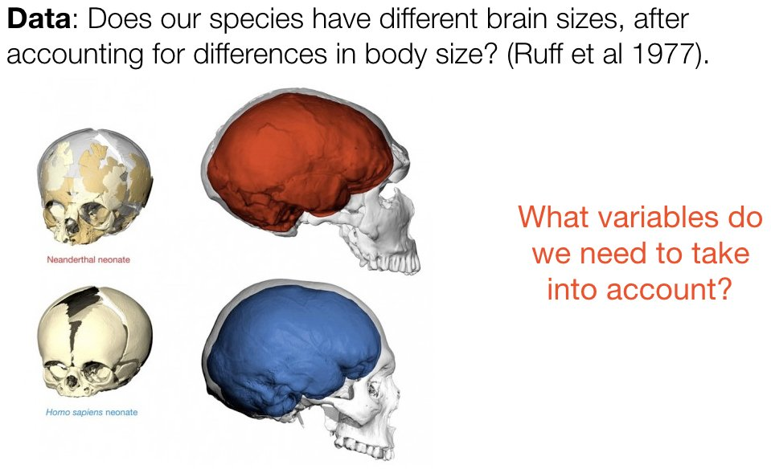

## ANCOVA: Neanderthal vs. Modern Human

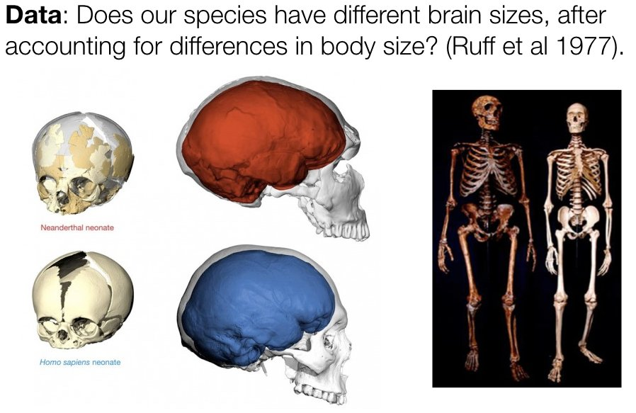

## ANCOVA: Brain-Body Mass Regression

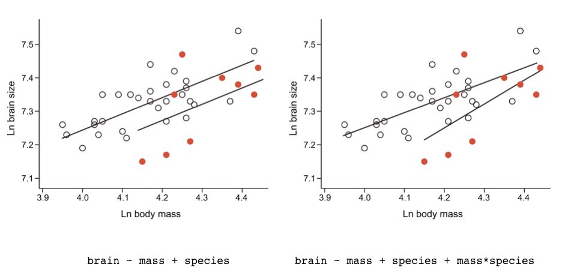

## ANCOVA: ANOVA vs. Covariate Adjustment

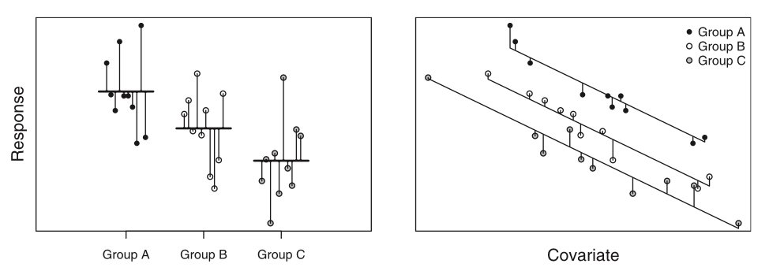

## ANCOVA: Adjusted Means

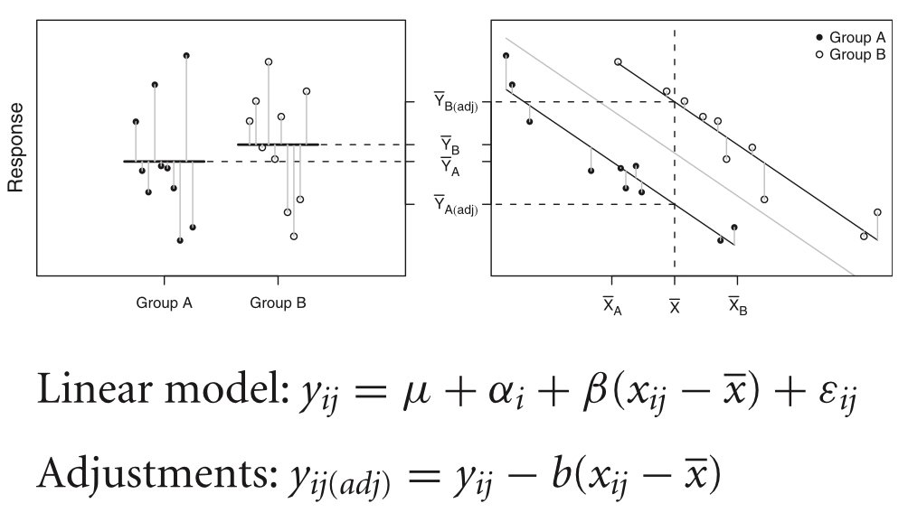

The key insight: by **adjusting for the covariate**, we can compare groups at the same value of the continuous predictor, removing confounding variation.

## ANCOVA: Multiple Covariates

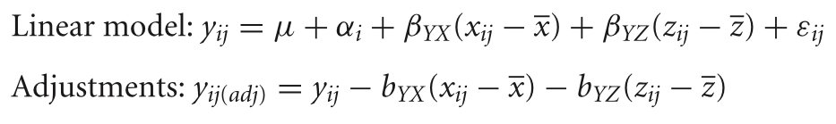

## ANCOVA: Null Hypotheses

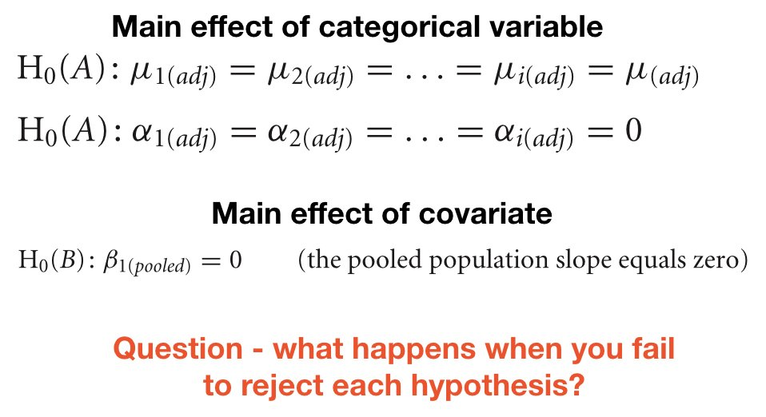

## ANCOVA: F-Ratio Table and Collinearity

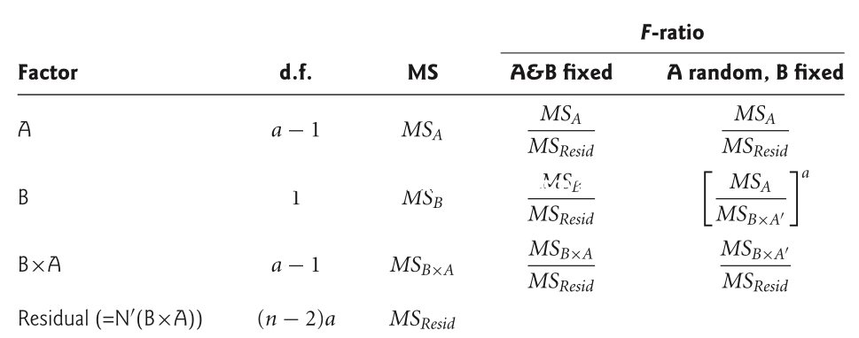

**Collinearity in ANCOVA**

If the covariate and the factor are correlated (e.g., body mass differs between species), the order in which terms enter the model matters. Use **Type II or Type III sums of squares** from the `car` package to handle this properly.

## ANCOVA: Heterogeneous Slopes

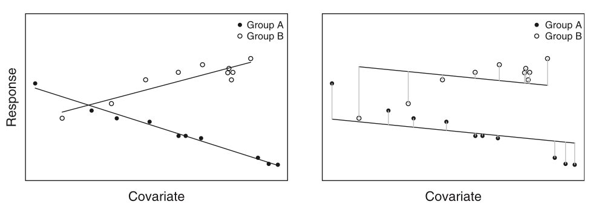

When slopes differ between groups, the interaction between the covariate and the factor is significant — this is a violation of the **parallel slopes assumption**.

## Parallel Slopes (Additive) Model

When there is no interaction, each group has the **same slope** but **different intercepts**:

- Equation
- LaTeX

$$y = \beta_0 + \beta_1 x_{continuous} + \beta_2 x_{categorical} + \epsilon_i$$

```
y = \beta_0 + \beta_1 x_{continuous} + \beta_2 x_{categorical} + \epsilon_i
```

```r
# Parallel slopes model (additive)
lm(response ~ continuous_var + factor_var, data = mydata)
```

- The `+` means “additive” — the effect of the covariate is the same in every group
- This produces parallel regression lines

## Interaction Model

When the relationship **differs between groups**, add an **interaction term**:

- Equation
- LaTeX

$$y = \beta_0 + \beta_1 x_1 + \beta_2 x_2 + \beta_3 (x_1 \times x_2) + \epsilon_i$$

```
y = \beta_0 + \beta_1 x_1 + \beta_2 x_2 + \beta_3 (x_1 \times x_2) + \epsilon_i
```

```r
# Model with interaction (different slopes)
lm(response ~ continuous_var * factor_var, data = mydata)

# Equivalent to:
lm(response ~ continuous_var + factor_var + continuous_var:factor_var,
   data = mydata)
```

## Interpreting ANCOVA Output

- Code
- Interpretation

```r
# Example with crickets data
lm(rate ~ temp + species, data = crickets)

# Output interpretation:
# (Intercept)      - baseline intercept for reference level
# temp             - slope (same for all groups)
# speciesO.niveus  - difference in intercept from reference
```

- The categorical variable coefficient represents the **offset from the reference group**
- This is the same dummy variable encoding that `lm()` uses for ANOVA
- The only difference from pure ANOVA is the inclusion of a continuous predictor

## Parallel vs. Interaction: When to Use

| Model | Use When | R Formula |
| --- | --- | --- |
| **Parallel Slopes** | Effect of covariate is same across groups | `y ~ x + group` |
| **Interaction** | Effect of covariate differs by group | `y ~ x * group` |

**Tip**

Always start with the interaction model. Test whether the interaction term is significant. If not, drop it and use the simpler parallel slopes model (parsimony principle).

## ANCOVA: Type II/III Sums of Squares

- Code
- When to Use

```r
library(car)

# Type II SS — tests each term after adjusting for all others
# (appropriate when no significant interaction)
Anova(lm(y ~ covariate + factor, data = mydata), type = "II")

# Type III SS — tests each term after adjusting for all others
# including interaction (appropriate when interaction is present)
Anova(lm(y ~ covariate * factor, data = mydata), type = "III")
```

| SS Type | Use When | Notes |
| --- | --- | --- |
| **Type I** | Balanced designs, order matters | Default in `anova()` |
| **Type II** | Unbalanced, no interaction | Default in `car::Anova()` |
| **Type III** | Unbalanced, interaction present | Requires `contr.sum` coding |

## Visualizing ANCOVA Models

- Output
- Code

[figure not shown]

```r
par(mfrow = c(1, 2))

# Parallel slopes
plot(x, y, col = ifelse(group == "A", "steelblue", "coral"), pch = 19,
     main = "Parallel Slopes Model")
abline(2, 0.8, col = "steelblue", lwd = 2)
abline(5, 0.8, col = "coral", lwd = 2)
legend("bottomright", c("Group A", "Group B"),
       col = c("steelblue", "coral"), pch = 19)

# Interaction model (different slopes)
plot(x, y2, col = ifelse(group == "A", "steelblue", "coral"), pch = 19,
     main = "Interaction Model (Different Slopes)")
abline(2, 0.5, col = "steelblue", lwd = 2)
abline(5, 1.2, col = "coral", lwd = 2)
```

## Dangers of Extrapolation

All regression models (including ANCOVA) are only valid **within the range of the observed data**:

- Polynomial models are especially dangerous to extrapolate — they can produce wildly unrealistic predictions outside the data range
- Even linear ANCOVA predictions become unreliable far from the observed covariate values
- Always report the range of your covariates alongside your model

**Rule of Thumb**

Never predict beyond the range of your observed data unless you have strong theoretical justification for the extrapolation.

# Multiple Linear Regression

## Why Multiple Regression?

Multiple linear regression extends simple regression to include **two or more predictor variables**. The goals are:

- Develop a better **predictive model** than possible from models based on single independent variables
- Investigate the **relative individual effects** of each predictor variable above and beyond the effects of the other variables
- The individual effects of each predictor on the response can be depicted by **partial regression lines**
- The slope of any partial regression line represents the rate of change of that predictor on the response, **holding all other predictors constant** at their means

## Additive and Multiplicative Models

**Additive model** — each predictor contributes independently:

- Equation
- LaTeX

$$y_i = \beta_0 + \beta_1 x_{i1} + \beta_2 x_{i2} + \ldots + \beta_j x_{ij} + \epsilon_i$$

```
y_i = \beta_0 + \beta_1 x_{i1} + \beta_2 x_{i2} + \ldots + \beta_j x_{ij} + \epsilon_i
```

**Multiplicative model** — includes an interaction between two predictors:

- Equation
- LaTeX

$$y_i = \beta_0 + \beta_1 x_{i1} + \beta_2 x_{i2} + \beta_3 x_{i1} x_{i2} + \epsilon_i$$

```
y_i = \beta_0 + \beta_1 x_{i1} + \beta_2 x_{i2} + \beta_3 x_{i1} x_{i2} + \epsilon_i
```

## Additive vs. Multiplicative Models

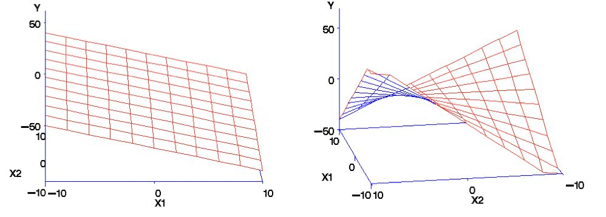

## R Example: Multiple Regression with 2 Predictors

Read in the RNAseq_lip.tsv and examine whether Gene01 and/or Gene02 expression levels influence lipid content.

- Code
- Questions

```r
RNAseq_Data <- read.table('RNAseq_lip.tsv', header = TRUE, sep = '\t')

y  <- RNAseq_Data$Lipid_Conc
g1 <- RNAseq_Data$Gene01
g2 <- RNAseq_Data$Gene02

# Multiplicative model (with interaction)
Mult_lm <- lm(y ~ g1 * g2)
summary(Mult_lm)
```

- What are the parameter estimates of interest?
- What are the outcomes from the hypothesis tests?
- What happens when you remove the interaction term?

## Additive Model Comparison

- Code
- Questions

```r
# Additive model (no interaction)
Add_lm <- lm(y ~ g1 + g2)
summary(Add_lm)
```

- Did any of the coefficient estimates change? Why?
- Did the degrees of freedom change? Why?
- Try different combinations of genes as predictors

## Multiple Regression Assumptions

Multiple regression carries all the assumptions of simple regression plus an additional one:

1. **Linearity** — the relationship between predictors and response is linear
2. **Normality** — residuals are normally distributed
3. **Homogeneity of variance** — constant variance of residuals
4. **Independence** — observations are independent
5. **No multicollinearity** — a predictor variable must not be strongly correlated with the combination of other predictor variables

**Multicollinearity**

When predictors are highly correlated, coefficient estimates become unstable, standard errors inflate, and interpretation becomes unreliable. Always check for collinearity before interpreting a multiple regression model.

## Checking for Multicollinearity

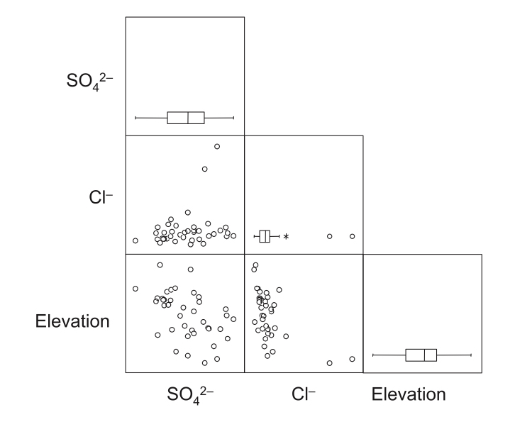

- Code
- Interpretation

```r
library(car)

# Visual check with scatterplot matrix
scatterplotMatrix(~ var1 + var2 + var3, diag = "boxplot")

# Variance Inflation Factor (VIF)
model <- lm(y ~ g1 + g2 + g3)
vif(model)

# Tolerance = 1/VIF (values < 0.1 indicate severe collinearity)
1 / vif(model)
```

| VIF Value | Interpretation |
| --- | --- |
| 1 | No collinearity |
| 1–5 | Moderate (usually acceptable) |
| 5–10 | High (investigate further) |
| > 10 | Severe (remedial action needed) |

## R Example: Three-Variable Regression

- Code
- Questions

```r
RNAseq_Data <- read.table('RNAseq_lip.tsv', header = TRUE, sep = '\t')
y  <- RNAseq_Data$Lipid_Conc
g1 <- RNAseq_Data$Gene01
g2 <- RNAseq_Data$Gene02
g3 <- RNAseq_Data$Gene03

# Three-predictor model
RNAseq3_lm <- lm(y ~ g1 + g2 + g3)
summary(RNAseq3_lm)
plot(RNAseq3_lm)

# Scatterplot matrices
library(car)
scatterplotMatrix(~ g1 + g2 + g3, diag = "boxplot")
scatterplotMatrix(~ y + g1 + g2 + g3, diag = "boxplot")

# Tolerance calculations (1 - R²)
1 / vif(lm(y ~ g1 + g2 + g3))
```

- Is there any evidence for multicollinearity?
- Try running a simple regression of `y ~ g3` alone — how does the slope estimate for Gene03 compare to the partial slope estimate from the full model?
- What does a change in slope estimate tell you about confounding?

## Bioengineering Example: Scaffold Properties and Tissue Growth

- Code
- Questions

```r
# Simulated bioengineering data: predicting tissue growth
# from scaffold porosity, stiffness, and cell seeding density
set.seed(42)
n <- 60

scaffold_data <- data.frame(
  porosity     = runif(n, 40, 90),         # percent porosity
  stiffness    = runif(n, 5, 50),          # kPa
  seeding_dens = runif(n, 1e4, 1e6)        # cells/mL
)
scaffold_data$tissue_growth <- with(scaffold_data,
  0.8 * porosity + 0.3 * stiffness - 0.00001 * seeding_dens +
  0.005 * porosity * stiffness + rnorm(n, 0, 8)
)

# Fit multiple regression
scaffold_lm <- lm(tissue_growth ~ porosity + stiffness + seeding_dens,
                   data = scaffold_data)
summary(scaffold_lm)
```

- Which scaffold properties significantly predict tissue growth?
- Does adding the interaction `porosity:stiffness` improve the model?
- What happens to the seeding density coefficient when you remove it?

## Diagnostic Plots for Multiple Regression

- Output
- Code
- Interpretation

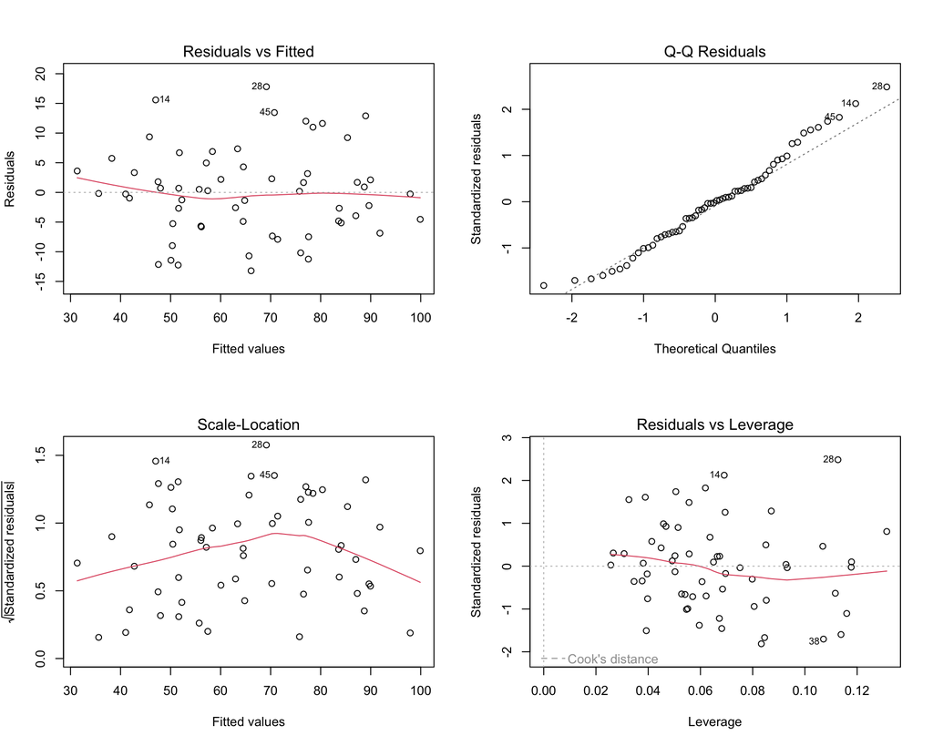

```r
# Standard diagnostic plots
par(mfrow = c(2, 2))
plot(scaffold_lm)

# Using ggfortify for prettier diagnostics
library(ggfortify)
autoplot(scaffold_lm, which = 1:4) + theme_minimal()

# Cook's distance — identify influential observations
cooks_d <- cooks.distance(scaffold_lm)
plot(cooks_d, type = "h", main = "Cook's Distance",
     ylab = "Cook's Distance", xlab = "Observation")
abline(h = 4 / n, col = "red", lty = 2)
```

- **Residuals vs Fitted**: look for non-linearity (curved pattern) or heteroscedasticity (funnel shape)
- **Q-Q Plot**: points should follow the diagonal line; deviations indicate non-normality
- **Scale-Location**: check for constant variance (flat trend line)
- **Residuals vs Leverage**: Cook’s distance > 4/n flags influential points

## Partial Regression Plots

Partial regression (added-variable) plots show the effect of each predictor **after adjusting for all others**:

- Output
- Code

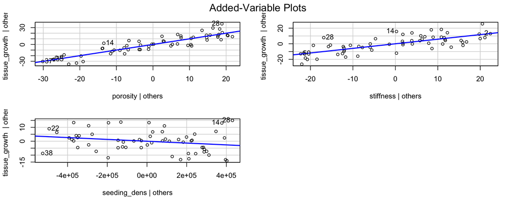

```r
library(car)

# Added-variable plots (partial regression plots)
avPlots(scaffold_lm)

# Each plot shows the relationship between one predictor
# and the response, holding all other predictors constant.
# The slope of each line equals the partial regression coefficient.
```

# Model Selection

## The Problem of Model Complexity

- How do we decide the complexity of a polynomial: straight line, quadratic, cubic, …?
- Which variables should we keep or discard when building a multiple regression model?
- How do we select from candidate models representing different biological processes?

**Principle of Parsimony**

“Models should be pared down until they are minimal and adequate” — Crawley 2007

If two or more models fit the data almost equally well, prefer the simpler model.

## Overfitting with Polynomials

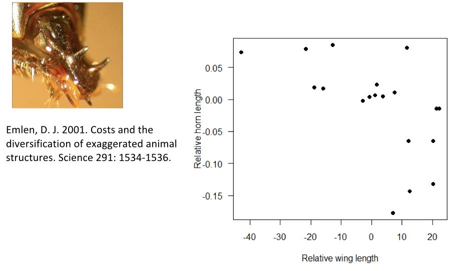

The log-likelihood and $R^2$ always increase with more parameters — but this does not mean the model is better!

## The Progression of Polynomial Fits

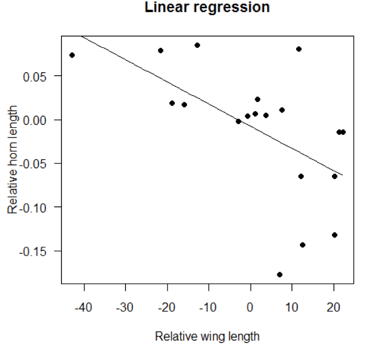

Linear fit

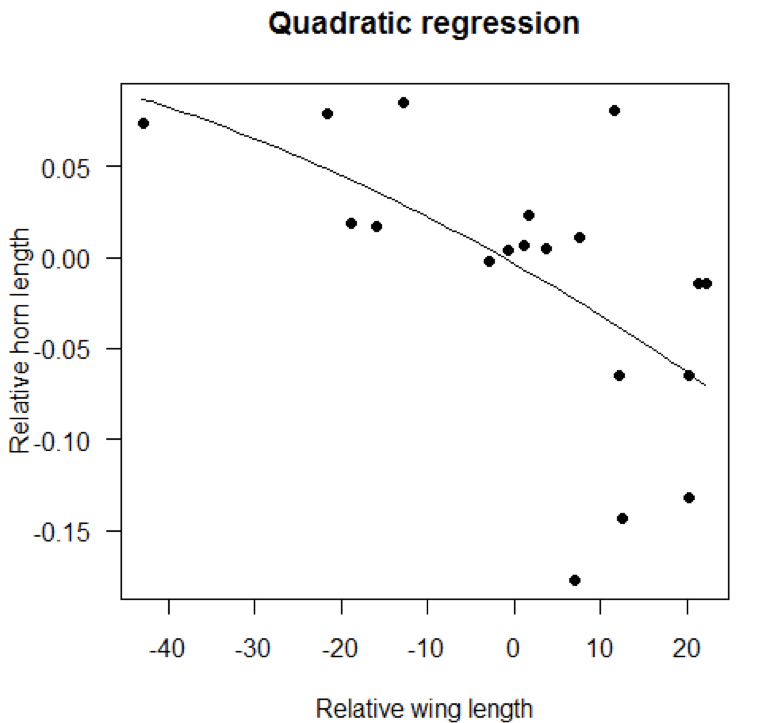

Quadratic fit

## Higher-Order Polynomials and Overfitting

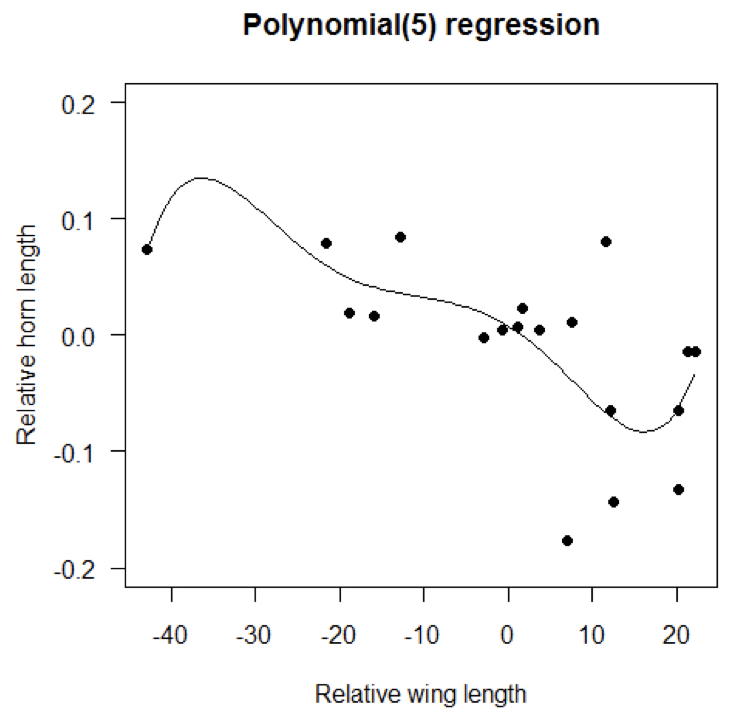

Degree 5 polynomial

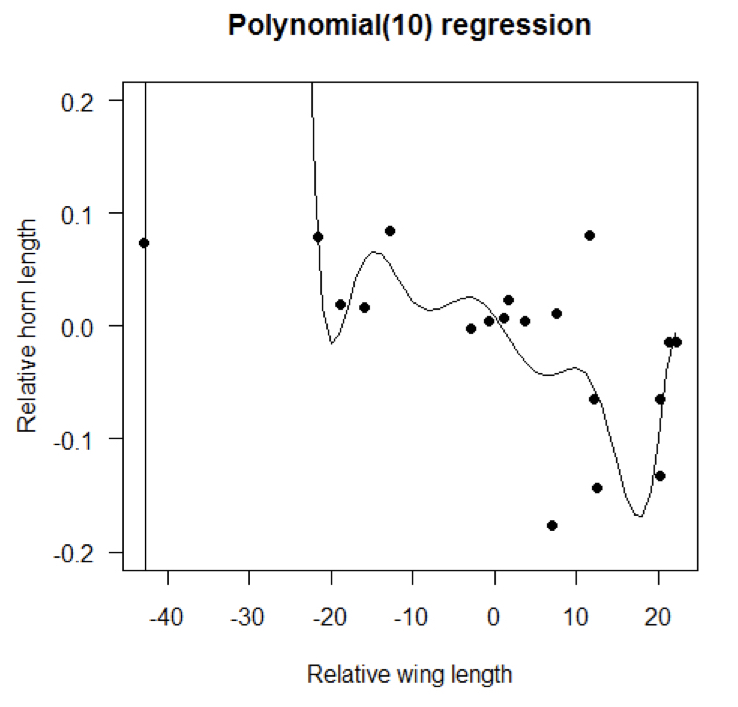

Degree 10 polynomial

As polynomial degree increases, the model fits the training data ever more closely — but becomes useless for prediction on new data.

## Model Selection Criteria

| Criterion | Description | Selection Rule |
| --- | --- | --- |
| **MS<sub>residuals</sub>** | Mean unexplained variation | Lowest value = best fit |
| **Adjusted R²** | Proportion of variance explained, penalized for # terms | Larger = better fit |
| **Mallow’s Cp** | Comparison to full model | Lowest value, or closest to p |
| **AIC** | Likelihood penalized by number of parameters | Smaller = more parsimonious |
| **BIC** | Like AIC but heavier penalty for complexity | Smaller = more parsimonious |

**Tip**

As a rule of thumb, if the difference between two AIC values (ΔAIC) is greater than 2, the lower AIC represents a meaningfully better model.

## Mallow’s Cp and All-Subsets Regression

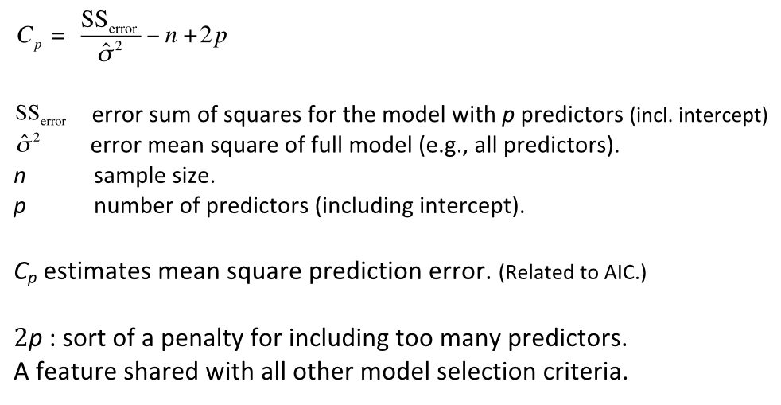

- Code
- Key Points

```r
library(leaps)

# All subsets regression
all_subsets <- regsubsets(y ~ g1 + g2 + g3 + g4, data = RNAseq_Data)
summary(all_subsets)

# Plot Cp, BIC, adjusted R²
par(mfrow = c(1, 3))
plot(all_subsets, scale = "Cp")
plot(all_subsets, scale = "bic")
plot(all_subsets, scale = "adjr2")
```

- **For prediction**: All models with Cp < p predict about equally well
- **For explanation**: If numerous models fit equally well, it is difficult to deduce which predictor “explains” the response
- **General caveat**: “Regression is not causation” — an experiment is needed for causal explanation

## Nested vs. Non-Nested Models

- **Nested (reduced vs. full)**: One model is a special case of the other — can compare with F-test or likelihood ratio test
- **Non-nested**: Models contain different sets of variables — compare with AIC or BIC
- Code
- Interpretation

```r
# Compare nested models with F-test
model_reduced <- lm(y ~ g1 + g2)
model_full    <- lm(y ~ g1 + g2 + g3)
anova(model_reduced, model_full)

# Compare non-nested models with AIC
AIC(model_a, model_b, model_c)
BIC(model_a, model_b, model_c)
```

- F-test p < 0.05 → the fuller model is significantly better
- Lower AIC/BIC → more parsimonious model
- BIC penalizes complexity more heavily than AIC

## Stepwise Model Selection in R

- Code
- Key Points

```r
# Start with a full model
full_model <- lm(tissue_growth ~ porosity * stiffness * seeding_dens,
                 data = scaffold_data)

# Forward stepwise selection (start from intercept-only)
null_model <- lm(tissue_growth ~ 1, data = scaffold_data)
forward_model <- step(null_model,
                      scope = list(lower = null_model, upper = full_model),
                      direction = "forward", trace = 1)

# Backward elimination (start from full model)
backward_model <- step(full_model, direction = "backward", trace = 1)

# Both directions
both_model <- step(null_model,
                   scope = list(lower = null_model, upper = full_model),
                   direction = "both", trace = 1)

# Compare final models
AIC(forward_model, backward_model, both_model)
BIC(forward_model, backward_model, both_model)
```

- `step()` uses AIC by default; add `k = log(n)` for BIC-based selection
- Forward selection can miss important combinations
- Backward elimination can fail when p > n
- “Both” direction is generally most robust
- Stepwise methods can overfit — always validate with cross-validation

# BREAK

# Statistical Power

## What is Power?

Power is the probability of correctly rejecting a **false** null hypothesis (i.e., detecting a real effect when one exists).

- Equation
- LaTeX

$$\text{Power} \propto \frac{(\text{Effect Size})(\alpha)(\sqrt{n})}{\sigma}$$

```
\text{Power} \propto \frac{(\text{Effect Size})(\alpha)(\sqrt{n})}{\sigma}
```

- Helps interpret failure to reject the null — was the test underpowered?
- Target: typically **80% power** (β = 0.20)

## Power Overview

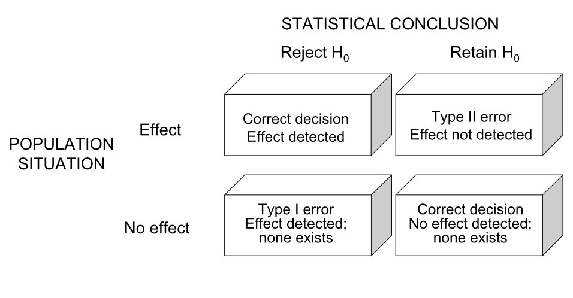

Statistical power and Type II error

## Key Components of Power

| Component | Description |
| --- | --- |
| **Effect Size (ES)** | Magnitude of difference to detect |
| **Standard Deviation (σ)** | Variability within groups |
| **Sample Size (n)** | Number of observations |
| **Significance Level (α)** | Usually 0.05 |
| **Power (1 − β)** | Usually 0.80 |

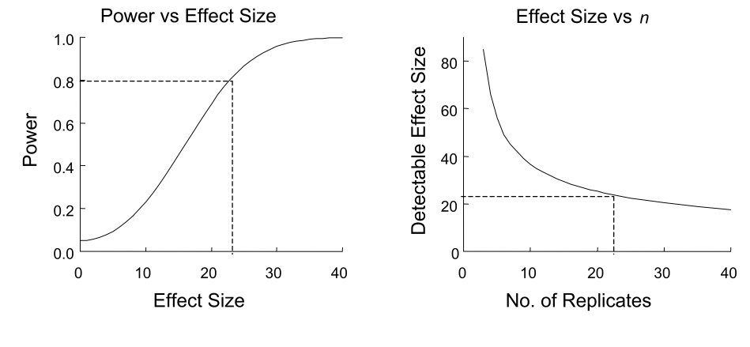

Key questions in power analysis

## Cohen’s d

Effect size between two group means expressed in standard deviation units:

- Equation
- LaTeX

$$d = \frac{\bar{x}_1 - \bar{x}_2}{s_{pooled}}$$

```
d = \frac{\bar{x}_1 - \bar{x}_2}{s_{pooled}}
```

| d | Interpretation |
| --- | --- |
| 0.2 | Small effect |
| 0.5 | Medium effect |
| 0.8 | Large effect |

## Power Analysis in R

- Output
- Code

```
Required n per group: 64
```

```r
library(pwr)

# Calculate required sample size for 80% power
sample_size <- pwr.t.test(
  d = 0.5,
  sig.level = 0.05,
  power = 0.80,
  type = "two.sample"
)

cat("Required n per group:", ceiling(sample_size$n))
```

## Power Curve

- Output
- Code

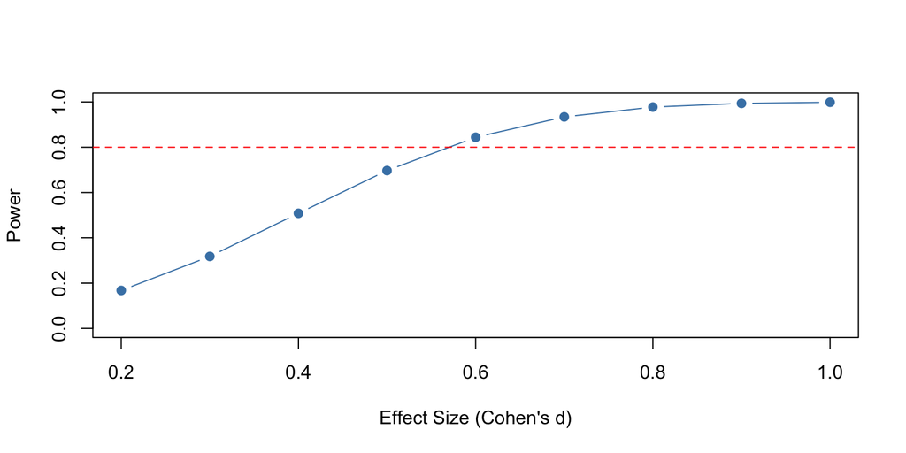

```r
effect_sizes <- seq(0.2, 1.0, by = 0.1)
power_values <- sapply(effect_sizes, function(d) {
  pwr.t.test(d = d, n = 50, sig.level = 0.05, type = "two.sample")$power
})

plot(effect_sizes, power_values, type = "b", pch = 19, col = "steelblue",
     xlab = "Effect Size (Cohen's d)", ylab = "Power", ylim = c(0, 1))
abline(h = 0.8, lty = 2, col = "red")
```

## Sample Size Curve

- Output
- Code

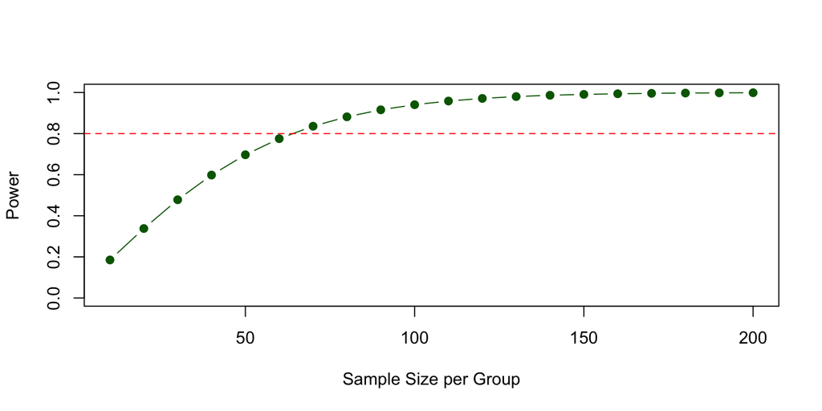

```r
sample_sizes <- seq(10, 200, by = 10)
power_by_n <- sapply(sample_sizes, function(n) {
  pwr.t.test(d = 0.5, n = n, sig.level = 0.05, type = "two.sample")$power
})

plot(sample_sizes, power_by_n, type = "b", pch = 19, col = "darkgreen",
     xlab = "Sample Size per Group", ylab = "Power", ylim = c(0, 1))
abline(h = 0.8, lty = 2, col = "red")
```

## Bootstrap Power Analysis

When parametric assumptions may not hold, use simulation-based power analysis:

- Code
- Key Points

```r
# Step 1: Simulate true populations
senior <- rpois(5000, lambda = 10)
fresh  <- rpois(5000, lambda = 12)

# Step 2: Draw samples and test
sample_s <- sample(senior, size = 10, replace = FALSE)
sample_f <- sample(fresh, size = 10, replace = FALSE)
t.test(sample_f, sample_s)

# Step 3: Replicate many times
samps_s <- replicate(n = 100, sample(senior, size = 10))
samps_f <- replicate(n = 100, sample(fresh, size = 10))

# Calculate power
tests <- data.frame(result = numeric(100))
for (i in 1:100) {
  tests$result[i] <- t.test(samps_s[, i], samps_f[, i])$p.value
}
power <- sum(tests$result < 0.05) / 100
cat("Estimated power:", power)
```

- This approach works for any distribution (Poisson, skewed, etc.)
- Increase the number of replicates (e.g., 1000+) for stable estimates
- Can modify sample sizes, effect sizes, or distributions to explore scenarios

## Power Analysis for ANOVA

- Code
- Cohen’s f

```r
library(pwr)

# Parameters for one-way ANOVA
effect_size_anova <- 0.25  # Cohen's f (medium)
alpha_anova <- 0.05
power_anova <- 0.8

# Calculate required sample size per group
sample_size_anova <- pwr.anova.test(
  k = 3,                    # Number of groups
  f = effect_size_anova,
  sig.level = alpha_anova,
  power = power_anova
)$n

cat("Sample Size per group for ANOVA:", ceiling(sample_size_anova))
```

Cohen’s f measures effect size in ANOVA:

| f | Interpretation |
| --- | --- |
| 0.10 | Small effect |
| 0.25 | Medium effect |
| 0.40 | Large effect |

Cohen’s f = √(variance between groups / variance within groups)

## Power Example: Bone Scaffold Experiment

A bioengineering lab needs to determine how many bone scaffolds to test to detect a 15% difference in compressive strength between two scaffold designs.

- Code
- Key Takeaway

```r
# Known from pilot data:
# Mean compressive strength: 50 MPa
# Standard deviation: 8 MPa
# Desired detectable difference: 15% = 7.5 MPa

effect_size_d <- 7.5 / 8  # Cohen's d = 0.94

scaffold_power <- pwr.t.test(
  d = effect_size_d,
  sig.level = 0.05,
  power = 0.80,
  type = "two.sample"
)

cat("Required scaffolds per group:", ceiling(scaffold_power$n))
cat("\nEffect size (Cohen's d):", round(effect_size_d, 2))
```

## Power for Factorial ANOVA

- Code
- Tip

```r
library(pwr)

# Power for a 2×3 factorial design
# (e.g., 2 scaffold materials × 3 growth factor concentrations)
pwr.anova.test(
  k = 6,           # Total number of cells (2 × 3)
  f = 0.30,        # Medium-large effect
  sig.level = 0.05,
  power = 0.80
)

# For interaction effects specifically:
# Interactions are typically harder to detect
# Use a smaller f value or plan for more samples
pwr.anova.test(
  k = 6,
  f = 0.20,        # Small-medium for interaction
  sig.level = 0.05,
  power = 0.80
)
```

Interactions typically have **smaller effect sizes** than main effects. Budget extra samples if detecting interactions is important to your study.

# Multifactor ANOVA

## Multifactor Designs Introduction

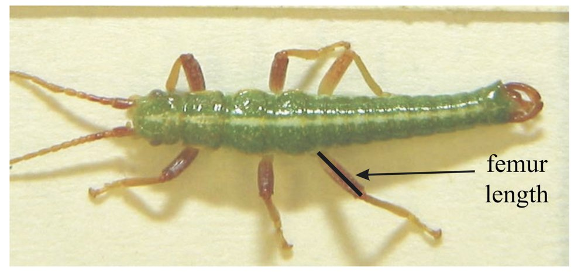

## Types of Factors

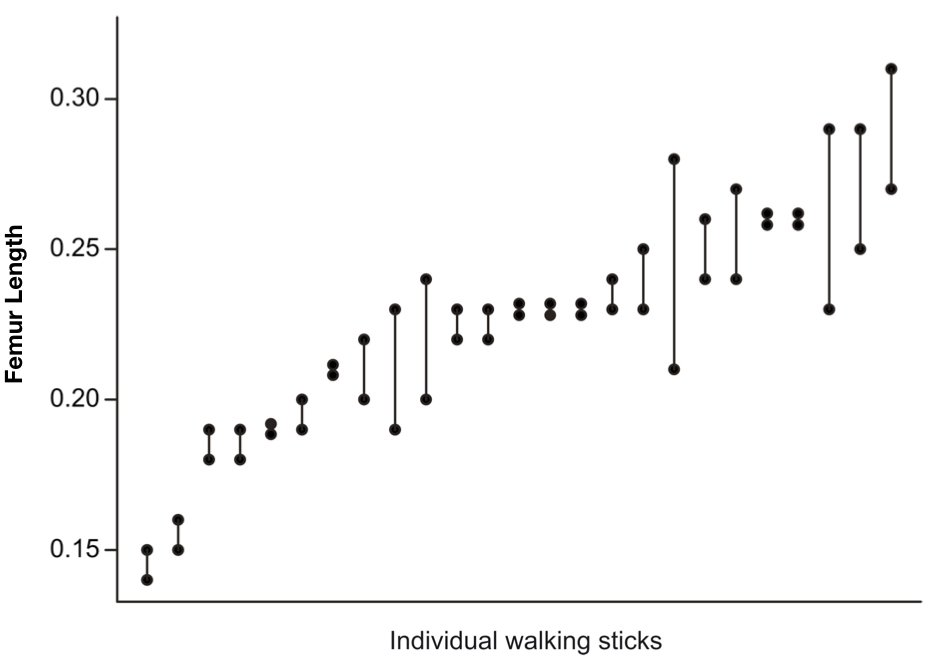

## Factor Levels

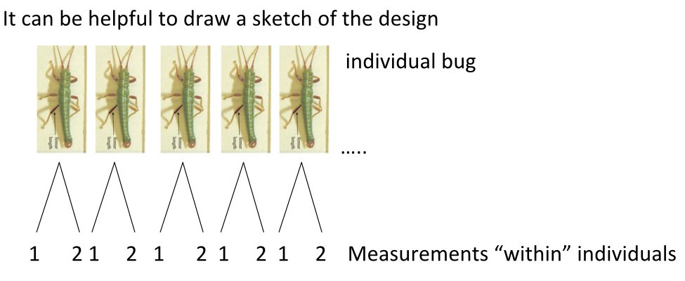

## Multifactor ANOVA Model

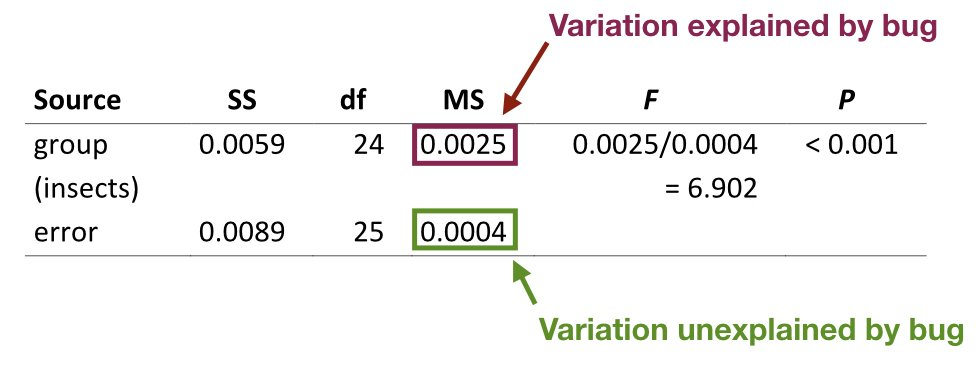

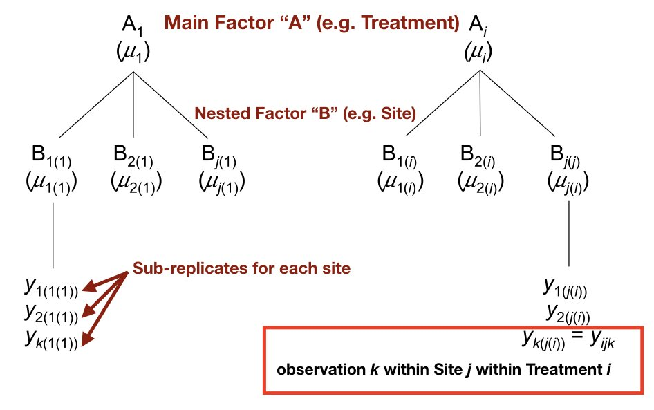

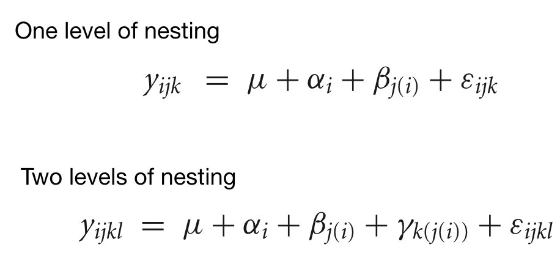

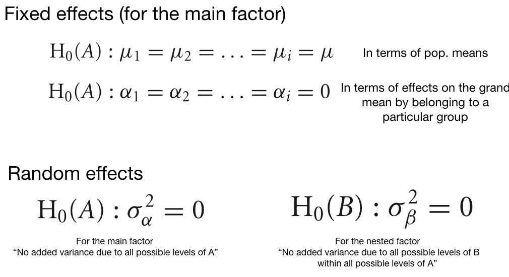

[figure not shown]

Intuition behind degrees of freedom